# R Notebook

# Visualising COVID-19

## 1. Introduction

In December 2019, COVID-19 coronavirus was first identified in the Wuhan region of China. By March 11, 2020, the World Health Organization (WHO) categorized the COVID-19 outbreak as a pandemic. A lot has happened in the months in between with major outbreaks in Iran, South Korea, and Italy.

We know that COVID-19 spreads through respiratory droplets, such as through coughing, sneezing, or speaking. But, how quickly did the virus spread across the globe? And, can we see any effect from country-wide policies, like shutdowns and quarantines? Fortunately, organizations around the world have been collecting data so that governments can monitor and learn from this pandemic. Notably, the Johns Hopkins University Center for Systems Science and Engineering created a publicly available data repository to consolidate this data from sources like the WHO, the Centers for Disease Control and Prevention (CDC), and the Ministry of Health from multiple countries.

In this notebook, we will visualize COVID-19 data from the first several weeks of the outbreak to see at what point this virus became a global pandemic.

## 2. Libraries and Data

```r
library(tidyquant)
```

## 3. Basic global daily trends

Let’s create a date rather than having day, month, year

| dateRep | day | month | year | cases | deaths | countriesAndTerritories | geoId | countryterritoryCode | popData2018 | continentExp | Date |
| --- | --- | --- | --- | --- | --- | --- | --- | --- | --- | --- | --- |
| 09/06/2020 | 9 | 6 | 2020 | 575 | 12 | Afghanistan | AF | AFG | 37172386 | Asia | 2020-06-09 |
| 08/06/2020 | 8 | 6 | 2020 | 791 | 30 | Afghanistan | AF | AFG | 37172386 | Asia | 2020-06-08 |
| 07/06/2020 | 7 | 6 | 2020 | 582 | 18 | Afghanistan | AF | AFG | 37172386 | Asia | 2020-06-07 |
| 06/06/2020 | 6 | 6 | 2020 | 915 | 9 | Afghanistan | AF | AFG | 37172386 | Asia | 2020-06-06 |
| 05/06/2020 | 5 | 6 | 2020 | 787 | 6 | Afghanistan | AF | AFG | 37172386 | Asia | 2020-06-05 |
| 04/06/2020 | 4 | 6 | 2020 | 758 | 24 | Afghanistan | AF | AFG | 37172386 | Asia | 2020-06-04 |
| 03/06/2020 | 3 | 6 | 2020 | 759 | 5 | Afghanistan | AF | AFG | 37172386 | Asia | 2020-06-03 |
| 02/06/2020 | 2 | 6 | 2020 | 545 | 8 | Afghanistan | AF | AFG | 37172386 | Asia | 2020-06-02 |
| 01/06/2020 | 1 | 6 | 2020 | 680 | 8 | Afghanistan | AF | AFG | 37172386 | Asia | 2020-06-01 |
| 31/05/2020 | 31 | 5 | 2020 | 866 | 3 | Afghanistan | AF | AFG | 37172386 | Asia | 2020-05-31 |

[output cut: 990 more lines]

| Date | total_cases | total_deaths |
| --- | --- | --- |
| 2019-12-31 | 27 | 0 |
| 2020-01-01 | 0 | 0 |
| 2020-01-02 | 0 | 0 |
| 2020-01-03 | 17 | 0 |
| 2020-01-04 | 0 | 0 |
| 2020-01-05 | 15 | 0 |
| 2020-01-06 | 0 | 0 |
| 2020-01-07 | 0 | 0 |
| 2020-01-08 | 0 | 0 |
| 2020-01-09 | 0 | 0 |

[output cut: 152 more lines]

We do a quick sanity check by plotting this data on a line graph (as it is time based)

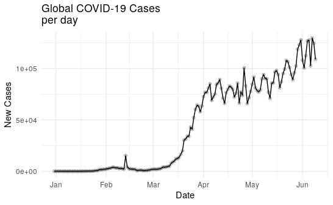

And the same for deaths

[figure not shown]

## Cumulative Global Data

| Date | total_cases | total_deaths |
| --- | --- | --- |
| 2019-12-31 | 27 | 0 |
| 2020-01-01 | 0 | 0 |
| 2020-01-02 | 0 | 0 |
| 2020-01-03 | 17 | 0 |
| 2020-01-04 | 0 | 0 |
| 2020-01-05 | 15 | 0 |
| 2020-01-06 | 0 | 0 |
| 2020-01-07 | 0 | 0 |
| 2020-01-08 | 0 | 0 |
| 2020-01-09 | 0 | 0 |

[output cut: 152 more lines]

We do the cumulative counts

| date | total_cases | total_deaths | cum_cases |
| --- | --- | --- | --- |
| 2019-12-31 | 27 | 0 | 27 |
| 2020-01-01 | 0 | 0 | 27 |
| 2020-01-02 | 0 | 0 | 27 |
| 2020-01-03 | 17 | 0 | 44 |
| 2020-01-04 | 0 | 0 | 44 |
| 2020-01-05 | 15 | 0 | 59 |
| 2020-01-06 | 0 | 0 | 59 |
| 2020-01-07 | 0 | 0 | 59 |
| 2020-01-08 | 0 | 0 | 59 |
| 2020-01-09 | 0 | 0 | 59 |

[output cut: 152 more lines]

And plot

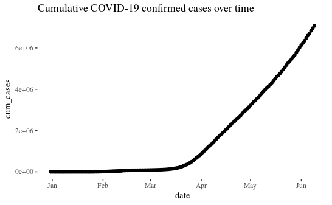

And the log10 version on the y axis

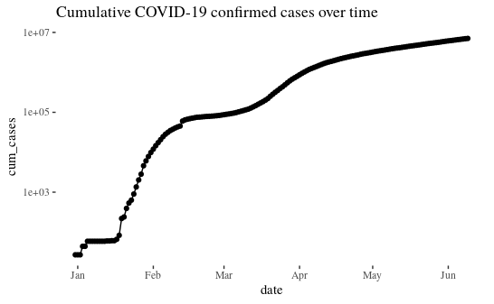

## By country

Let’s now group by countries and look at individual national trends across the world

| countriesAndTerritories | total_cases | total_deaths |
| --- | --- | --- |
| Afghanistan | 20917 | 369 |
| Albania | 1263 | 34 |
| Algeria | 10265 | 715 |
| Andorra | 852 | 51 |
| Angola | 92 | 4 |
| Anguilla | 3 | 0 |
| Antigua_and_Barbuda | 26 | 3 |
| Argentina | 23607 | 693 |
| Armenia | 13325 | 211 |
| Aruba | 101 | 3 |

[output cut: 200 more lines]

This is useful but it would also be useful to have some cumulative case and death counts for every country so that we can filter countries we wish to examine

| countriesAndTerritories | total_cases | total_deaths |
| --- | --- | --- |
| United_States_of_America | 1961185 | 111007 |
| Brazil | 691758 | 36455 |
| Russia | 476658 | 5971 |
| United_Kingdom | 287399 | 40597 |
| India | 266598 | 7466 |
| Spain | 241717 | 27136 |
| Italy | 235278 | 33964 |
| Peru | 199696 | 5571 |
| Germany | 184543 | 8711 |
| Iran | 173832 | 8351 |

[output cut: 6 more lines]

[figure not shown]

```r
ggplot(by_country, aes(Date, total_cases)) +
  geom_line() +
  labs(
    title = "Cumulative COVID-19 Cases\nper day",
    ylab = "Cases",
    xlab = "Date"
  ) +
  facet_wrap(~countriesAndTerritories, drop=TRUE, ncol = 4, scales="free_y") +
  theme_minimal()
```

[output not shown]

## 4. Normal vs under-reporting of deaths

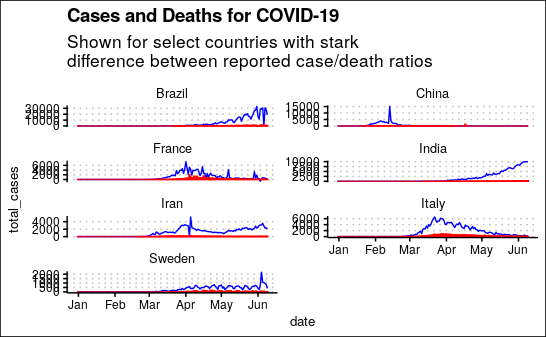

It is clear that in some countries there under-reporting of deaths. Let’s separate out some key suspects

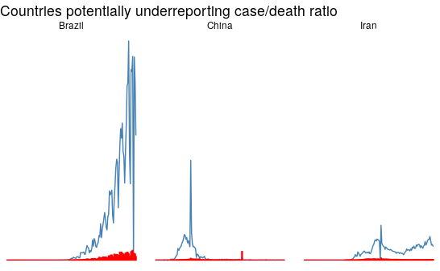

Compared to more typical countries

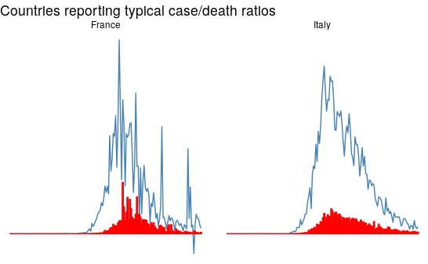